# Ensemble_Techniques_Project

### Data Description

#### Attribute Information

- name - ASCII subject name and recording number
- MDVP:Fo(Hz) - Average vocal fundamental frequency
- MDVP:Fhi(Hz) - Maximum vocal fundamental frequency
- MDVP:Flo(Hz) - Minimum vocal fundamental frequency
- MDVP:Jitter(%),MDVP:Jitter(Abs),MDVP:RAP,MDVP:PPQ,Jitter:DDP - Several measures of variation in fundamental frequency
- MDVP:Shimmer,MDVP:Shimmer(dB),Shimmer:APQ3,Shimmer:APQ5,MDVP:APQ,Shimmer:DDA - Several measures of variation in amplitude
- NHR,HNR - Two measures of ratio of noise to tonal components in the voice
- status - Tarhet Variable. Health status of the subject (one) - Parkinson's, (zero) - healthy
- RPDE,D2 - Two nonlinear dynamical complexity measures
- DFA - Signal fractal scaling exponent
- spread1,spread2,PPE - Three nonlinear measures of fundamental frequency variation 9. car name: string (unique for each instance)

### Objective

Goal is to classify the patients into the respective labels using the attributes from their voice recordings

### Import the necessary libraries

```python
import numpy as np
import pandas as pd
import seaborn as sns
import matplotlib.pyplot as plt
%matplotlib inline

from sklearn.preprocessing import StandardScaler
from sklearn import model_selection
from sklearn.model_selection import train_test_split
from sklearn import metrics

from sklearn.model_selection import train_test_split
from sklearn.linear_model import LogisticRegression
from sklearn.neighbors import KNeighborsClassifier
from sklearn.naive_bayes import GaussianNB
from sklearn.svm import SVC

from mlxtend.classifier import StackingClassifier

from sklearn.ensemble import RandomForestClassifier
from sklearn.ensemble import AdaBoostClassifier
from sklearn.ensemble import BaggingClassifier
import warnings

sns.set_style(style='darkgrid')  # Setting the plot style. Purely for aesthetic purposes
warnings.simplefilter('ignore')
```

### 1. Load the dataset

```python
data = pd.read_csv("Data - Parkinsons.csv")
data.head(5)
```

|  | name | MDVP:Fo(Hz) | MDVP:Fhi(Hz) | MDVP:Flo(Hz) | MDVP:Jitter(%) | MDVP:Jitter(Abs) | MDVP:RAP | MDVP:PPQ | Jitter:DDP | MDVP:Shimmer | ... | Shimmer:DDA | NHR | HNR | status | RPDE | DFA | spread1 | spread2 | D2 | PPE |
| --- | --- | --- | --- | --- | --- | --- | --- | --- | --- | --- | --- | --- | --- | --- | --- | --- | --- | --- | --- | --- | --- |
| 0 | phon_R01_S01_1 | 119.992 | 157.302 | 74.997 | 0.00784 | 0.00007 | 0.00370 | 0.00554 | 0.01109 | 0.04374 | ... | 0.06545 | 0.02211 | 21.033 | 1 | 0.414783 | 0.815285 | -4.813031 | 0.266482 | 2.301442 | 0.284654 |
| 1 | phon_R01_S01_2 | 122.400 | 148.650 | 113.819 | 0.00968 | 0.00008 | 0.00465 | 0.00696 | 0.01394 | 0.06134 | ... | 0.09403 | 0.01929 | 19.085 | 1 | 0.458359 | 0.819521 | -4.075192 | 0.335590 | 2.486855 | 0.368674 |
| 2 | phon_R01_S01_3 | 116.682 | 131.111 | 111.555 | 0.01050 | 0.00009 | 0.00544 | 0.00781 | 0.01633 | 0.05233 | ... | 0.08270 | 0.01309 | 20.651 | 1 | 0.429895 | 0.825288 | -4.443179 | 0.311173 | 2.342259 | 0.332634 |
| 3 | phon_R01_S01_4 | 116.676 | 137.871 | 111.366 | 0.00997 | 0.00009 | 0.00502 | 0.00698 | 0.01505 | 0.05492 | ... | 0.08771 | 0.01353 | 20.644 | 1 | 0.434969 | 0.819235 | -4.117501 | 0.334147 | 2.405554 | 0.368975 |
| 4 | phon_R01_S01_5 | 116.014 | 141.781 | 110.655 | 0.01284 | 0.00011 | 0.00655 | 0.00908 | 0.01966 | 0.06425 | ... | 0.10470 | 0.01767 | 19.649 | 1 | 0.417356 | 0.823484 | -3.747787 | 0.234513 | 2.332180 | 0.410335 |

5 rows × 24 columns

### 2. It is always a good practice to eye-ball raw data to get a feel of the data in terms of number of records, structure of the file, number of attributes, types of attributes and a general idea of likely challenges in the dataset. Mention a few comments in this regard (5 points)

```python
data['status'] = data['status'].astype('category')
data.info()
```

```
<class 'pandas.core.frame.DataFrame'>
RangeIndex: 195 entries, 0 to 194
Data columns (total 24 columns):
name                195 non-null object
MDVP:Fo(Hz)         195 non-null float64
MDVP:Fhi(Hz)        195 non-null float64
MDVP:Flo(Hz)        195 non-null float64
MDVP:Jitter(%)      195 non-null float64
MDVP:Jitter(Abs)    195 non-null float64
MDVP:RAP            195 non-null float64
MDVP:PPQ            195 non-null float64
Jitter:DDP          195 non-null float64
MDVP:Shimmer        195 non-null float64
MDVP:Shimmer(dB)    195 non-null float64
Shimmer:APQ3        195 non-null float64
Shimmer:APQ5        195 non-null float64
MDVP:APQ            195 non-null float64
Shimmer:DDA         195 non-null float64
NHR                 195 non-null float64
HNR                 195 non-null float64
status              195 non-null category
RPDE                195 non-null float64
DFA                 195 non-null float64
spread1             195 non-null float64
spread2             195 non-null float64
D2                  195 non-null float64
PPE                 195 non-null float64
dtypes: category(1), float64(22), object(1)
memory usage: 35.4+ KB
```

- The dataset is of shape (195,24)
- No sign of missing values
- All the columns instead of name column are read as numeric columns (either float or int)
- Continuous and kinda continuous columns : MDVP:Fo(Hz), MDVP:Fhi(Hz), MDVP:Flo(Hz), MDVP:Jitter(%), MDVP:Jitter(Abs), MDVP:RAP, MDVP:PPQ, Jitter:DDP, MDVP:Shimmer, MDVP:Shimmer(dB), Shimmer:APQ3, Shimmer:APQ5, MDVP:APQ, Shimmer:DDA, NHR, HNR, RPDE, DFA, spread1, spread2, D2, PPE
- Categorical columns : status

```python
predictors = data.select_dtypes(include='number')
print(f'Predictors: {list(predictors.columns)}')
```

```
Predictors: ['MDVP:Fo(Hz)', 'MDVP:Fhi(Hz)', 'MDVP:Flo(Hz)', 'MDVP:Jitter(%)', 'MDVP:Jitter(Abs)', 'MDVP:RAP', 'MDVP:PPQ', 'Jitter:DDP', 'MDVP:Shimmer', 'MDVP:Shimmer(dB)', 'Shimmer:APQ3', 'Shimmer:APQ5', 'MDVP:APQ', 'Shimmer:DDA', 'NHR', 'HNR', 'RPDE', 'DFA', 'spread1', 'spread2', 'D2', 'PPE']
```

```python
labels = data.select_dtypes(include='category')
print(f'Labels: {list(labels.columns)}')
```

```
Labels: ['status']
```

```python
data.describe().T  # descriptive statistics of each of the attributes
```

|  | count | mean | std | min | 25% | 50% | 75% | max |
| --- | --- | --- | --- | --- | --- | --- | --- | --- |
| MDVP:Fo(Hz) | 195.0 | 154.228641 | 41.390065 | 88.333000 | 117.572000 | 148.790000 | 182.769000 | 260.105000 |
| MDVP:Fhi(Hz) | 195.0 | 197.104918 | 91.491548 | 102.145000 | 134.862500 | 175.829000 | 224.205500 | 592.030000 |
| MDVP:Flo(Hz) | 195.0 | 116.324631 | 43.521413 | 65.476000 | 84.291000 | 104.315000 | 140.018500 | 239.170000 |
| MDVP:Jitter(%) | 195.0 | 0.006220 | 0.004848 | 0.001680 | 0.003460 | 0.004940 | 0.007365 | 0.033160 |
| MDVP:Jitter(Abs) | 195.0 | 0.000044 | 0.000035 | 0.000007 | 0.000020 | 0.000030 | 0.000060 | 0.000260 |
| MDVP:RAP | 195.0 | 0.003306 | 0.002968 | 0.000680 | 0.001660 | 0.002500 | 0.003835 | 0.021440 |
| MDVP:PPQ | 195.0 | 0.003446 | 0.002759 | 0.000920 | 0.001860 | 0.002690 | 0.003955 | 0.019580 |
| Jitter:DDP | 195.0 | 0.009920 | 0.008903 | 0.002040 | 0.004985 | 0.007490 | 0.011505 | 0.064330 |
| MDVP:Shimmer | 195.0 | 0.029709 | 0.018857 | 0.009540 | 0.016505 | 0.022970 | 0.037885 | 0.119080 |
| MDVP:Shimmer(dB) | 195.0 | 0.282251 | 0.194877 | 0.085000 | 0.148500 | 0.221000 | 0.350000 | 1.302000 |
| Shimmer:APQ3 | 195.0 | 0.015664 | 0.010153 | 0.004550 | 0.008245 | 0.012790 | 0.020265 | 0.056470 |
| Shimmer:APQ5 | 195.0 | 0.017878 | 0.012024 | 0.005700 | 0.009580 | 0.013470 | 0.022380 | 0.079400 |
| MDVP:APQ | 195.0 | 0.024081 | 0.016947 | 0.007190 | 0.013080 | 0.018260 | 0.029400 | 0.137780 |
| Shimmer:DDA | 195.0 | 0.046993 | 0.030459 | 0.013640 | 0.024735 | 0.038360 | 0.060795 | 0.169420 |
| NHR | 195.0 | 0.024847 | 0.040418 | 0.000650 | 0.005925 | 0.011660 | 0.025640 | 0.314820 |
| HNR | 195.0 | 21.885974 | 4.425764 | 8.441000 | 19.198000 | 22.085000 | 25.075500 | 33.047000 |
| RPDE | 195.0 | 0.498536 | 0.103942 | 0.256570 | 0.421306 | 0.495954 | 0.587562 | 0.685151 |
| DFA | 195.0 | 0.718099 | 0.055336 | 0.574282 | 0.674758 | 0.722254 | 0.761881 | 0.825288 |
| spread1 | 195.0 | -5.684397 | 1.090208 | -7.964984 | -6.450096 | -5.720868 | -5.046192 | -2.434031 |
| spread2 | 195.0 | 0.226510 | 0.083406 | 0.006274 | 0.174351 | 0.218885 | 0.279234 | 0.450493 |
| D2 | 195.0 | 2.381826 | 0.382799 | 1.423287 | 2.099125 | 2.361532 | 2.636456 | 3.671155 |
| PPE | 195.0 | 0.206552 | 0.090119 | 0.044539 | 0.137451 | 0.194052 | 0.252980 | 0.527367 |

### 3. Using univariate & bivariate analysis to check the individual attributes for their basic statistics such as central values, spread, tails, relationships between variables etc. mention your observations

**Univariate analysis of each attribute**

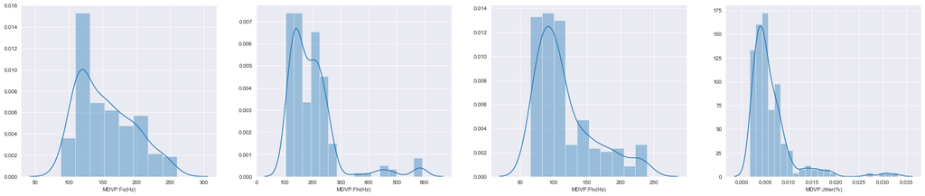

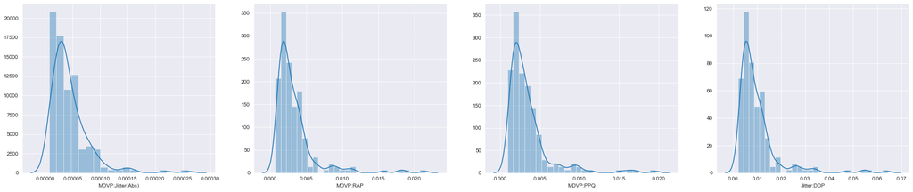

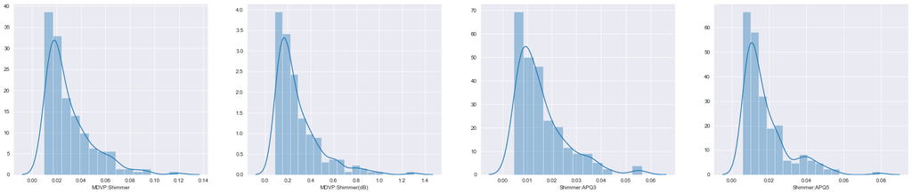

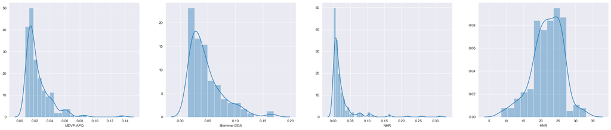

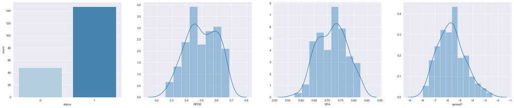

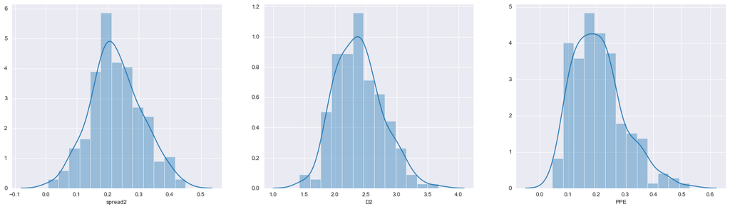

```python
data.drop('name', axis=1, inplace=True)

pos = 1    # a variable to manage the position of the subplot in the overall plot
for feature in data.columns:   # for-loop to iterate over every attribute whose distribution is to be visualized
    if pos == 1:
        plt.figure(figsize= (30,20))  # Set the figure size

    plt.subplot(3, 4, pos)   # plot grid
    if feature != 'status':   # Plot histogram for all the continuous columns
        sns.distplot(data[feature], kde= True )
    else:
        sns.countplot(data[feature], palette= 'Blues')    # Plot bar chart for all the categorical columns

    pos += 1  # to plot over the grid one by one
    if pos > 4:
        pos = 1
```

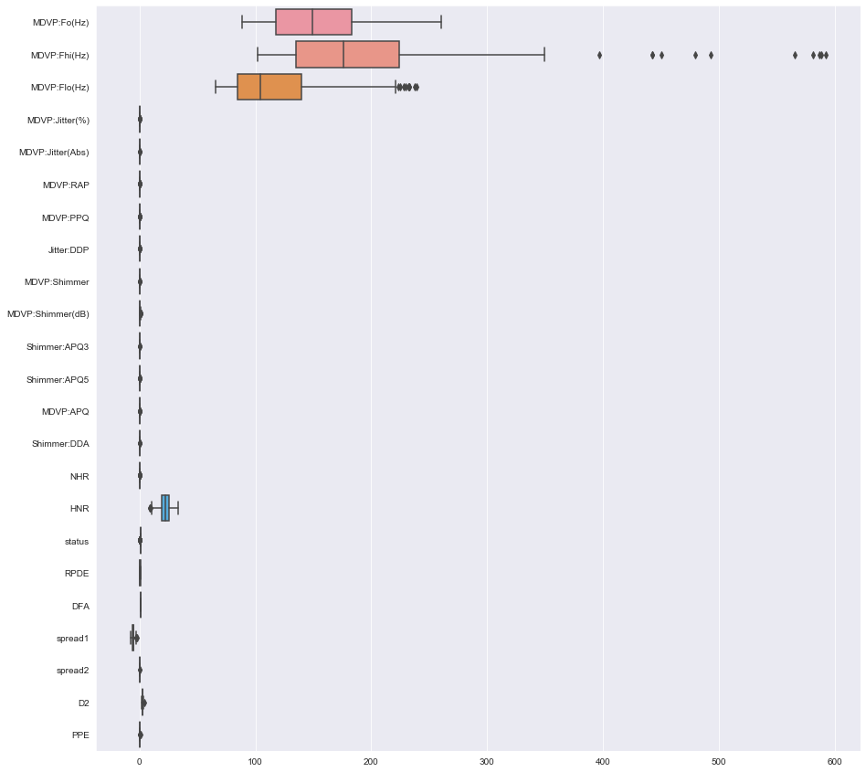

```python
plt.figure(figsize=(15,15))
sns.boxplot(data=data, orient='h')
```

**Multivariate analysis**

```
(22.0, 0.0)
```

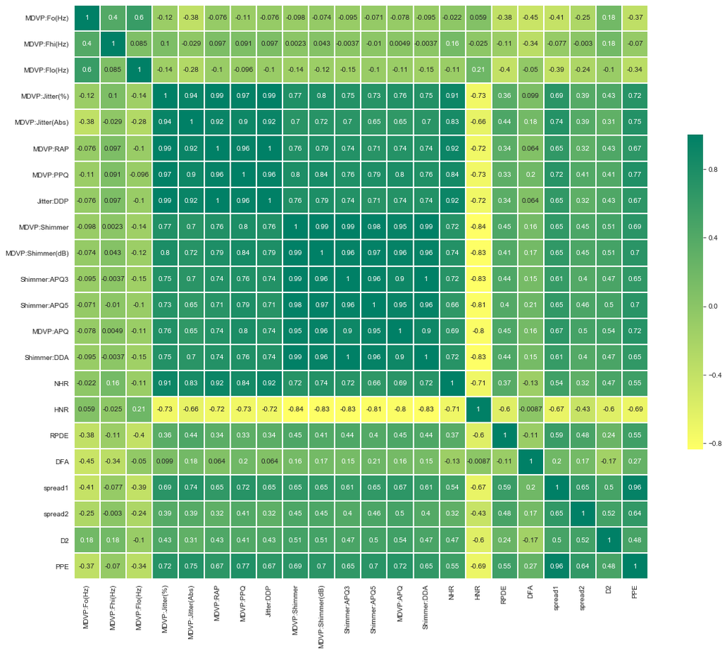

```python
plt.figure(figsize = (20,15))
sns.set_style(style = 'white')
g = sns.heatmap(data.corr(), annot=True, cmap = 'summer_r', square=True, linewidth=1, cbar_kws={'fraction' : 0.02})
g.set_yticklabels(g.get_yticklabels(), rotation=0, horizontalalignment='right')
bottom, top = g.get_ylim()
g.set_ylim(bottom + 0.5, top - 0.5)
```

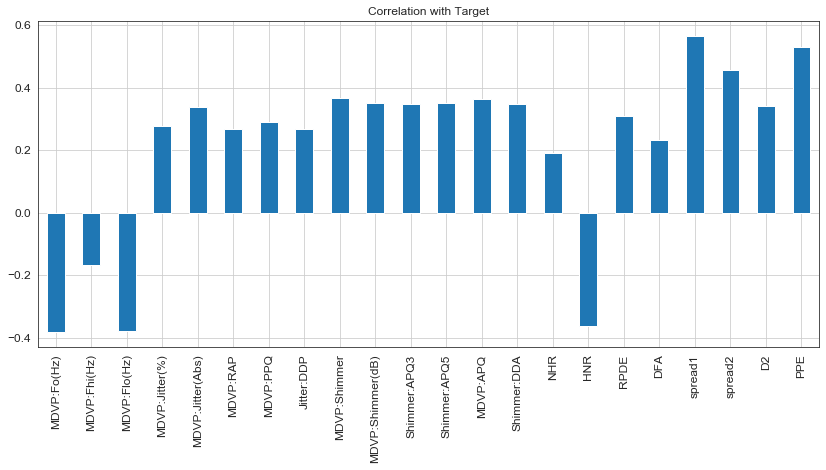

```python
# Correlation with Target
predictors.corrwith(data.status).plot.bar(figsize = (14, 6), title = "Correlation with Target", fontsize = 12, grid = True)
```

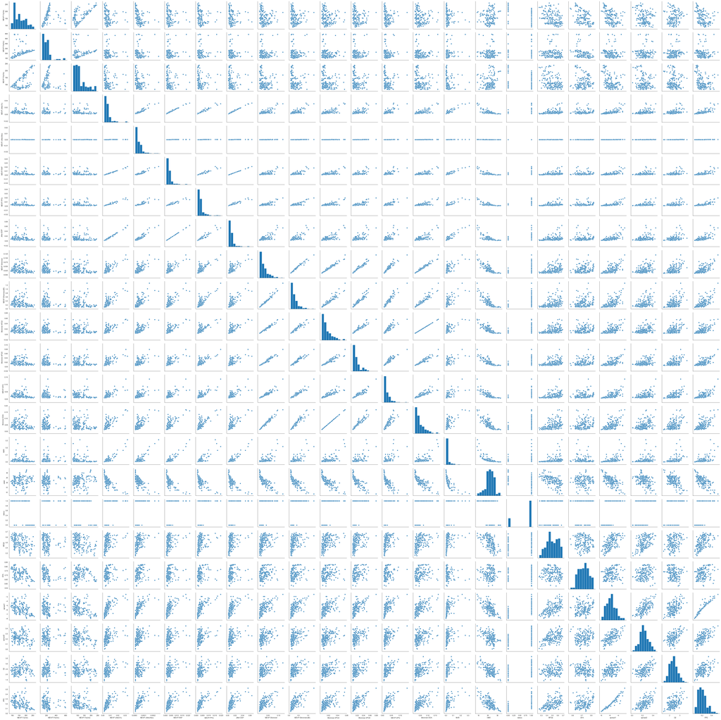

```python
sns.pairplot(data)
plt.show()
```

- Jitter:DDP is highly correlated with the MDVP:Jitter(%), MDVP:RAP and MDVP:PPQ
- MDVP:APQ is highly correlated with the MDVP:Shimmer and MDVP:Shimmer(dB)
- MDVP:Jitter(%) is highly correlated with the MDVP:RAP, MDVP:PPQ and Jitter:DDP
- MDVP:PPQ is highly correlated with the MDVP:Jitter(%), MDVP:RAP and Jitter:DDP
- MDVP:RAP is highly correlated with the MDVP:Jitter(%), MDVP:PPQ and Jitter:DDP
- MDVP:Shimmer is highly correlated with the MDVP:Shimmer(dB), Shimmer:APQ3, Shimmer:APQ5, MDVP:APQ and Shimmer:DDA
- MDVP:Shimmer(dB) is highly correlated with the MDVP:Shimmer, Shimmer:APQ3, Shimmer:APQ5, MDVP:APQ and Shimmer:DDA
- Shimmer:APQ3 is highly correlated with the MDVP:Shimmer, MDVP:Shimmer(dB), Shimmer:APQ5 and Shimmer:DDA
- Shimmer:APQ5 is highly correlated with the MDVP:Shimmer, MDVP:Shimmer(dB), Shimmer:APQ3 and Shimmer:DDA
- Shimmer:DDA is highly correlated with the MDVP:Shimmer, MDVP:Shimmer(dB), Shimmer:APQ3 amd Shimmer:APQ5
- PPE is highly correlated with the spread1

### 4. Split the dataset into training and test set in the ratio of 70:30 (Training:Test)

#### Prepare data for training

- **Seperate Predictors from the target**
- **Split the data into test and train sets**

```python
X = predictors # Predictors

y = labels # target

# Split data into test and train
X_train, X_test, y_train, y_test = train_test_split(X,y, random_state = 1, stratify = y, test_size=0.30)
```

#### Feature importance

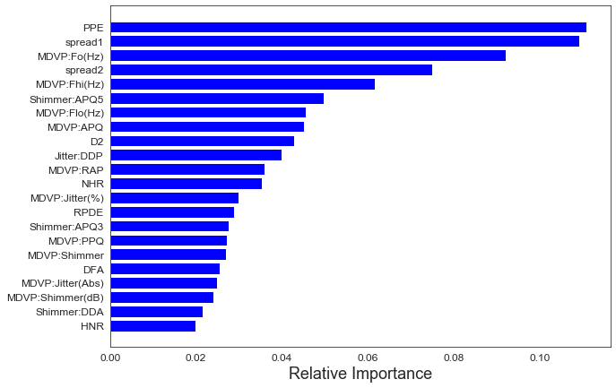

```python
from sklearn.ensemble import RandomForestClassifier
rf_clf = RandomForestClassifier(n_estimators=500, n_jobs=-1, random_state=42)
rf_clf.fit(X_train, y_train)

features = list(X_train.columns)
importances = rf_clf.feature_importances_
indices = np.argsort(importances)

fig, ax = plt.subplots(figsize=(10, 7))
plt.barh(range(len(indices)), importances[indices], color='b', align='center')
ax.tick_params(axis="x", labelsize=12)
ax.tick_params(axis="y", labelsize=12)
plt.yticks(range(len(indices)), [features[i] for i in indices])
plt.xlabel('Relative Importance', fontsize = 18)
```

```python
print(f'Shape of train data set: {X_train.shape}')
print(f'Shape of test data set: {X_test.shape}')
```

```
Shape of train data set: (136, 22)
Shape of test data set: (59, 22)
```

### 5. Prepare the data for training - Scale the data if necessary, get rid of missing values (if any) etc

- **Standardize the continuous attributes**

```python
# fitting a scaler function to scale test and train to avoid data leakage aka to keep the sanctity of the test data

scaler = StandardScaler()   # A scaler function

X_train = scaler.fit_transform(X_train)
X_test  = scaler.fit_transform(X_test)
```

### Since we will be using multiple models using the same data, thhe following is a user defined function for that purpose

```python
def fit_n_print(model, X_train, X_test, y_train, y_test):  # take the model, and data as inputs

    # fit the model with the train data
    model.fit(X_train, y_train)

    # Predict the response for test dataset
    y_predict = model.predict(X_test)

    score     = metrics.accuracy_score(y_test, y_predict)
    recall    = metrics.recall_score(y_test, y_predict)
    precision = metrics.precision_score(y_test, y_predict)
    f1_score  = metrics.f1_score(y_test, y_predict)

    return score, recall, precision, f1_score  # return all the metrics
```

### 6. Train at least 3 standard classification algorithms - Logistic Regression, Naive Bayes’, SVM, k-NN etc, and note down their accuracies on the test data

```python
lr = LogisticRegression(solver = 'liblinear', random_state=1)  #
lr_accuracy, lr_recall, lr_precision, lr_f1_score = fit_n_print(lr, X_train, X_test, y_train, y_test)

knn = KNeighborsClassifier(n_neighbors=5)
knn_accuracy, knn_recall, knn_precision, knn_f1_score = fit_n_print(knn, X_train, X_test, y_train, y_test )

nb = GaussianNB()
nb_accuracy, nb_recall, nb_precision, nb_f1_score = fit_n_print(nb, X_train, X_test, y_train, y_test )

svm = SVC(gamma = 'auto', kernel= 'poly', degree=2)
svm_accuracy, svm_recall, svm_precision, svm_f1_score = fit_n_print(svm, X_train, X_test, y_train, y_test )
```

```python
result1 = pd.DataFrame({'Model' : ['Logistic Regression', 'KNN', "Naive Bayes'", 'SVM'],
                      'Accuracy': [ lr_accuracy ,  knn_accuracy ,  nb_accuracy ,  svm_accuracy ],
                      'Recall' : [lr_recall ,  knn_recall ,  nb_recall ,  svm_recall ],
                      'Precision': [lr_precision ,  knn_precision ,  nb_precision ,  svm_precision ],
                      'F1 Score' : [lr_f1_score, knn_f1_score, nb_f1_score, svm_f1_score]})

result1.sort_values(by=['Accuracy', 'F1 Score'], axis=0, ascending=False, inplace=False, kind='quicksort', na_position='last')
```

|  | Model | Accuracy | Recall | Precision | F1 Score |
| --- | --- | --- | --- | --- | --- |
| 1 | KNN | 0.932203 | 0.977273 | 0.934783 | 0.955556 |
| 0 | Logistic Regression | 0.881356 | 0.954545 | 0.893617 | 0.923077 |
| 3 | SVM | 0.830508 | 0.977273 | 0.826923 | 0.895833 |
| 2 | Naive Bayes' | 0.728814 | 0.704545 | 0.911765 | 0.794872 |

### 7. Train a meta-classifier and note the accuracy on test data

```python
knnc = KNeighborsClassifier(n_neighbors=5)
rfc = RandomForestClassifier(random_state=1, n_estimators = 50)
nbc = GaussianNB()
abc = AdaBoostClassifier( n_estimators= 100, learning_rate=0.1, random_state=1)
bgc = BaggingClassifier(n_estimators=50, max_samples= .7, bootstrap=True, oob_score=True, random_state=1)
lrc = LogisticRegression(solver = 'liblinear')

sclf = StackingClassifier(classifiers=[knnc, rfc, nbc, abc, bgc],
                          meta_classifier=lrc, use_probas=True)

print('3-fold cross validation:\n')

for clf, label in zip([knnc, rfc, nbc, abc, bgc, sclf],
                      ['KNN',
                       'Random Forest',
                       'Naive Bayes',
                       'AdaBoost',
                       'Bagging',
                       'StackingClassifier']):

    scores = model_selection.cross_val_score(clf, X, y, cv=3, scoring='accuracy')
    print("Accuracy: %0.2f (+/- %0.2f) [%s]" % (scores.mean(), scores.std(), label))
```

```
3-fold cross validation:

Accuracy: 0.76 (+/- 0.06) [KNN]
Accuracy: 0.82 (+/- 0.06) [Random Forest]
Accuracy: 0.68 (+/- 0.01) [Naive Bayes]
Accuracy: 0.79 (+/- 0.04) [AdaBoost]
Accuracy: 0.82 (+/- 0.05) [Bagging]
Accuracy: 0.84 (+/- 0.07) [StackingClassifier]
```

```python
sclf.fit(X_train, y_train)

y_pred = sclf.predict(X_test)

stacking_score = metrics.accuracy_score(y_test, y_pred)
print(f'Stacking Classifier Accuracy: {stacking_score:.4f}')
```

```
Stacking Classifier Accuracy: 0.9153
```

```python
from sklearn.ensemble import VotingClassifier
from sklearn.tree import DecisionTreeClassifier
from sklearn.ensemble import ExtraTreesClassifier

kn_clf = KNeighborsClassifier(n_neighbors=5),
bg_clf = BaggingClassifier(DecisionTreeClassifier(), n_estimators=50, max_samples= .7, bootstrap=True, oob_score=True),
et_clf = ExtraTreesClassifier(n_estimators = 50),
rf_clf = RandomForestClassifier(n_estimators = 100),
ab_clf = AdaBoostClassifier(n_estimators= 50),
sv_clf = SVC(C = 10, kernel = 'rbf')


estimator = []
estimator.append(('kn_clf', KNeighborsClassifier(n_neighbors=5)))
estimator.append(('bg_clf', BaggingClassifier(DecisionTreeClassifier(), n_estimators=50, max_samples= .7, bootstrap=True, oob_score=True)))
estimator.append(('et_clf', ExtraTreesClassifier(n_estimators = 50)))
estimator.append(('rf_clf', RandomForestClassifier(n_estimators = 100)))
estimator.append(('ab_clf', AdaBoostClassifier(n_estimators= 50)))
estimator.append(('sv_clf', SVC(C = 10, kernel = 'rbf', probability = True)))


voting_clf_hard = VotingClassifier(estimators = estimator, voting='hard')
voting_clf_soft = VotingClassifier(estimators = estimator, voting='soft')

voting_clf_hard.fit(X_train, y_train)
```

[output not shown]

```python
y_pred = voting_clf_hard.predict(X_test)
score = accuracy_score(y_test, y_pred, normalize = True)
print(score)
```

```
0.9322033898305084
```

```python
voting_clf_soft.fit(X_train, y_train)
y_pred = voting_clf_soft.predict(X_test)
score = accuracy_score(y_test, y_pred, normalize = True)
print(score)
```

```
0.9152542372881356
```

### 8. Train at least one standard Ensemble model - Random forest, Bagging, Boosting etc, and note the accuracy

```python
# Random Forest Classifier
rf = RandomForestClassifier(n_estimators = 50, random_state=1, n_jobs=1)
rf_accuracy, rf_recall, rf_precision, rf_f1_score = fit_n_print(rf, X_train, X_test, y_train, y_test)

# AdaBoost Classifier
ab = AdaBoostClassifier( n_estimators= 100, learning_rate=0.1)
ab_accuracy, ab_recall, ab_precision, ab_f1_score = fit_n_print(ab, X_train, X_test, y_train, y_test)

# Bagging Classifier
bg = BaggingClassifier(n_estimators=50, max_samples= .7, bootstrap=True, oob_score=True)
bg_accuracy, bg_recall, bg_precision, bg_f1_score = fit_n_print(bg, X_train, X_test, y_train, y_test)
```

```python
result2 = pd.DataFrame({'Model' : ['Random Forest', 'AdaBoost', 'Bagging'],
                      'Accuracy': [ rf_accuracy, ab_accuracy, bg_accuracy ],
                      'Recall' : [rf_recall , ab_recall, bg_recall ],
                      'Precision': [rf_precision , ab_precision, bg_precision ],
                      'F1 Score' : [rf_f1_score, ab_f1_score, bg_f1_score]})

result2.sort_values(by=['Accuracy', 'F1 Score'], axis=0, ascending=False, inplace=False, kind='quicksort', na_position='last')
```

|  | Model | Accuracy | Recall | Precision | F1 Score |
| --- | --- | --- | --- | --- | --- |
| 2 | Bagging | 0.915254 | 1.000000 | 0.897959 | 0.946237 |
| 0 | Random Forest | 0.881356 | 0.977273 | 0.877551 | 0.924731 |
| 1 | AdaBoost | 0.864407 | 0.977273 | 0.860000 | 0.914894 |

### 9. Compare all the models (minimum 5) and pick the best one among them

```python
result1.set_index('Model', inplace = True)
result2.set_index('Model', inplace = True)
```

```python
all_models = pd.concat([result1, result2])
all_models.sort_values(by=['Accuracy', 'F1 Score'], axis=0, ascending=False, kind='quicksort')
```

| Model | Accuracy | Recall | Precision | F1 Score |
| --- | --- | --- | --- | --- |
| KNN | 0.932203 | 0.977273 | 0.934783 | 0.955556 |
| Bagging | 0.915254 | 1.000000 | 0.897959 | 0.946237 |
| Random Forest | 0.881356 | 0.977273 | 0.877551 | 0.924731 |
| Logistic Regression | 0.881356 | 0.954545 | 0.893617 | 0.923077 |
| AdaBoost | 0.864407 | 0.977273 | 0.860000 | 0.914894 |
| SVM | 0.830508 | 0.977273 | 0.826923 | 0.895833 |
| Naive Bayes' | 0.728814 | 0.704545 | 0.911765 | 0.794872 |

KNN seems to be the go-to model for this dataset.